# HAS: Qualtrics Demographic

Shuying Yu

3/30/2022

# Introduction

Data of the *cleaned* sample of Healthy Aging Participants, meaning that these are participants that we have decided to include based on complete fMRI scans, no major health problems from demographic survey, and from previous team discussions of who to exclude as we wrapped up recruitment for the study.

Subjects ranged from 301-437, scanned over the course of March 1, 2017 to February 10, 2022.

Age characteristics of ALL HAS sample.

| Group | Count | Mean Age (years) | Standard Deviation of Age (years) | Minimum Age (years) | Maximum Age (years) |
| --- | --- | --- | --- | --- | --- |
| Pre | 34 | 47.32 | 2.31 | 43 | 51 |
| Peri | 34 | 50.76 | 2.18 | 45 | 54 |
| Post | 31 | 54.03 | 3.06 | 48 | 60 |
| Female | 99 | 50.60 | 3.72 | 43 | 60 |
| Male | 38 | 51.03 | 4.31 | 44 | 60 |
| Total | 137 | 50.72 | 3.88 | 43 | 60 |

Age characteristics of cleaned HAS sample.

| Group | Count | Mean Age (years) | Standard Deviation of Age (years) | Minimum Age (years) | Maximum Age (years) |
| --- | --- | --- | --- | --- | --- |
| Pre | 32 | 47.38 | 2.37 | 43 | 51 |
| Peri | 27 | 51.04 | 2.08 | 45 | 54 |
| Post | 26 | 53.92 | 2.90 | 50 | 60 |
| Female | 85 | 50.54 | 3.65 | 43 | 60 |
| Male | 30 | 50.50 | 4.09 | 44 | 60 |
| Total | 115 | 50.53 | 3.75 | 43 | 60 |

Please refer to hand out for means and standard deviations of the basic demographic and neuropsychological batteries. Figures will only include basic demographic and neuropsychiatric batteries.

# Basic Demographics

Age (years), BMI, highest completed level of education (years), and verbal IQ

**Age:** Ranges from 43-60 years old

**BMI:** Healthy adult BMI levels are about 19-25

**Education:**

- Some College or Associate’s = 14 years
- Bachelor’s = 16 years
- Master’s = 18 years
- Doctoral = 20 years

## Reproductive Status

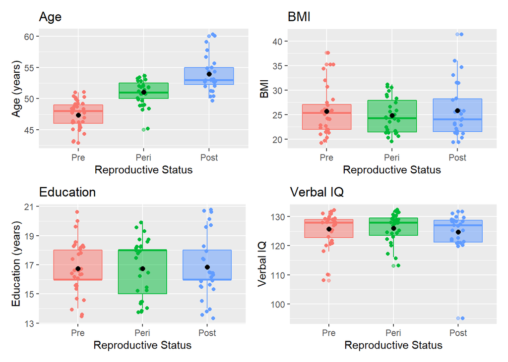

## Sex

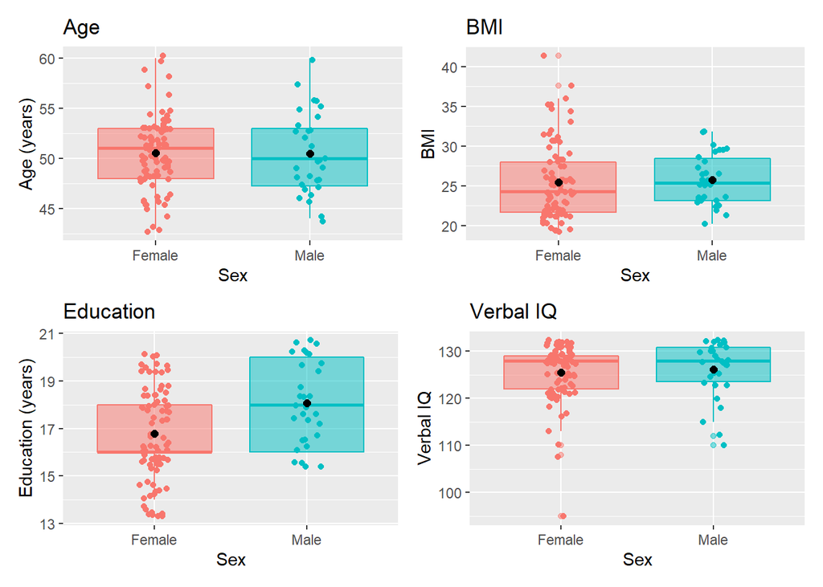

## Total

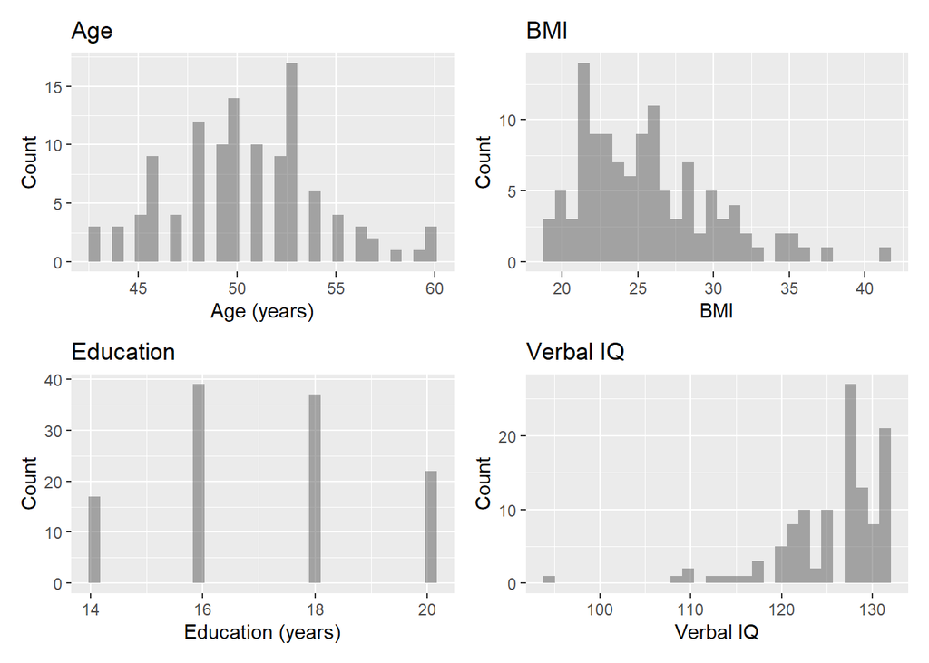

# Reproductive Health Characteristics

Women only. Includes only age at menarche (years) and time since last menstrual cycle (years).

Age characteristics of clean HAS sample of women, by reproductive stages.

| Reproductive Status | Straw-10 Stages | Count | Mean Age (years) | Standard Deviation of Age (years) | Minimum Age (years) | Maximum Age (years) |
| --- | --- | --- | --- | --- | --- | --- |
| Pre | -3a | 22 | 47.95 | 2.13 | 43 | 51 |
| Pre | -3a (maybe) | 1 | 48.00 | NA | 48 | 48 |
| Pre | -3b | 9 | 45.89 | 2.52 | 43 | 51 |
| Peri | -1 | 15 | 51.00 | 2.48 | 45 | 54 |
| Peri | -2 | 12 | 51.08 | 1.56 | 48 | 53 |
| Post | 1a | 7 | 53.43 | 2.07 | 50 | 57 |
| Post | 1b | 7 | 52.14 | 1.21 | 50 | 53 |
| Post | 1c | 9 | 54.67 | 3.16 | 50 | 60 |
| Post | 2 | 3 | 57.00 | 4.36 | 52 | 60 |

## Reproductive Status

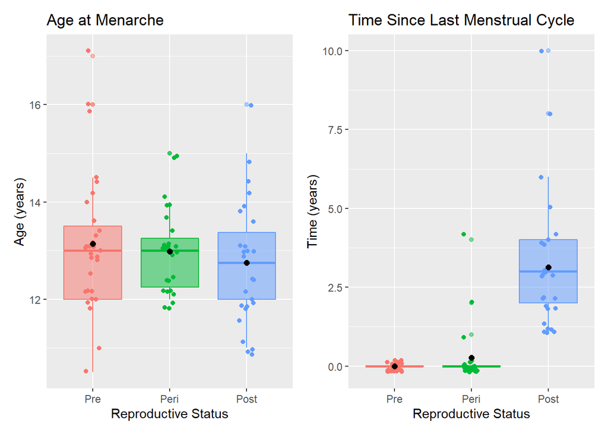

## Total

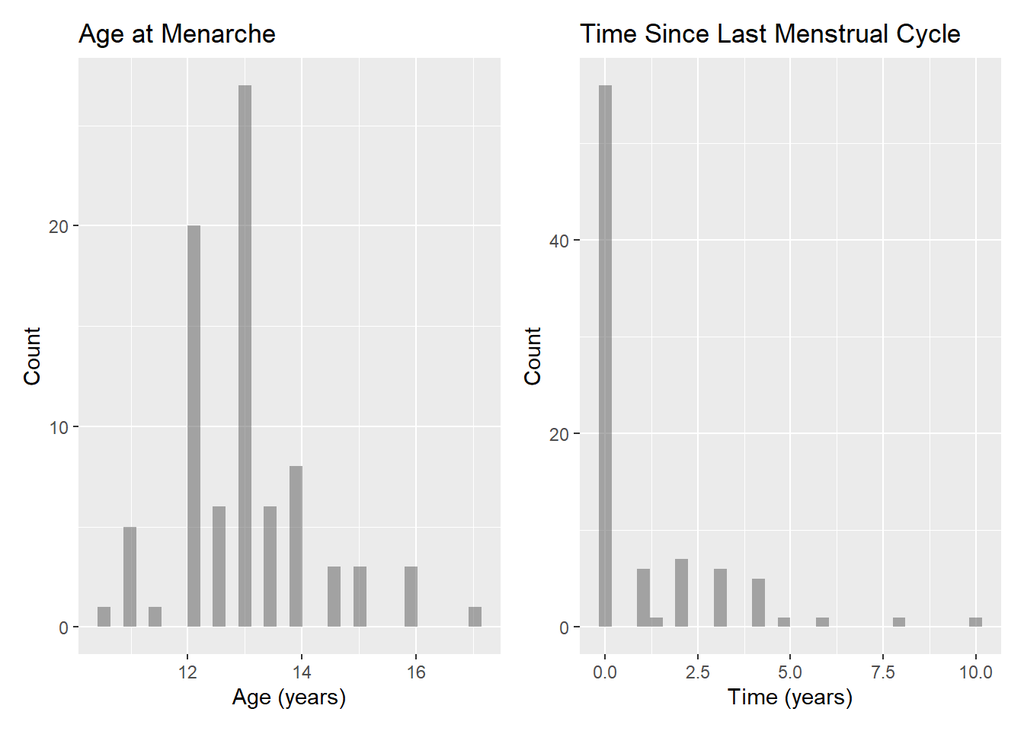

# Neuropsychiatric Assessments

## Edinburgh Handedness

Meaures handedness (most are right handed)

- Score of -1.0 = Pure Left Hander
- Score of -0.5 = Mixed Left Hander
- Score of 0.0 = Neutral
- Score of +0.5 = Mixed Right Hander
- Score of +1.0 = Pure Right Hander

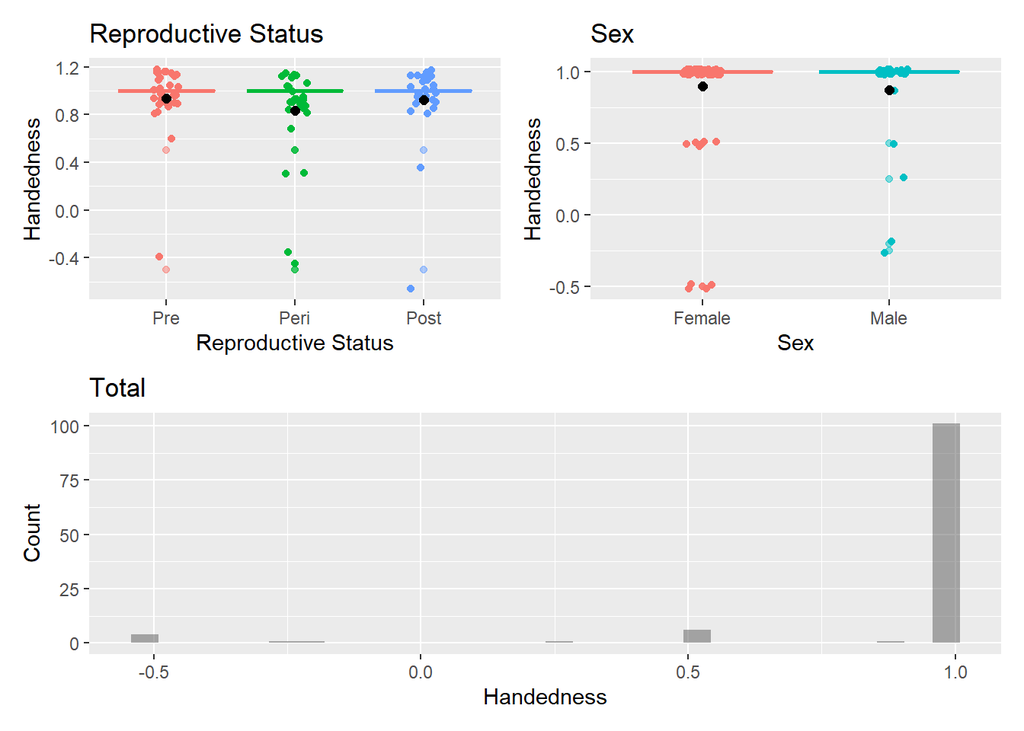

## Epworth Sleepiness

Measures whether participant is abnormally sleepy

- Score of 0-7 = Unlikely to be abnormally sleepy
- Score of 8-9 = Average amount of daytime sleepiness
- Score of 10-15 = May be excessively sleepy depending on situation
- Score of 16-24 = Excessively sleepy

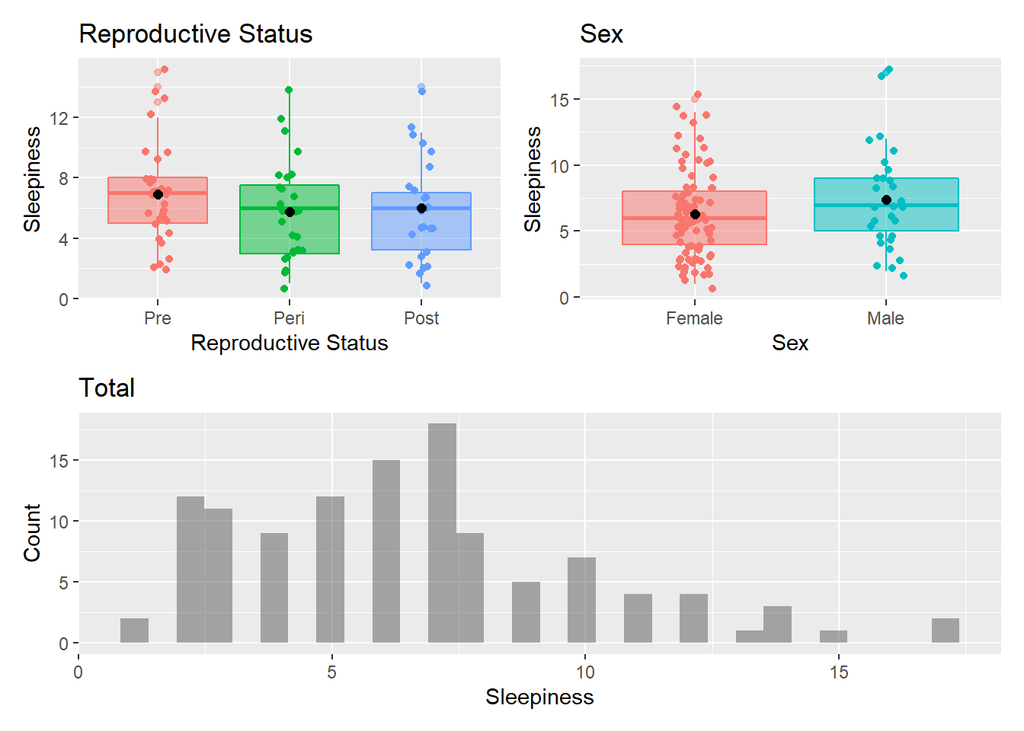

## Barratt

Measures personality and behavior impulsivity. Higher scores indicate more impulsivity.

**Overall/Total**

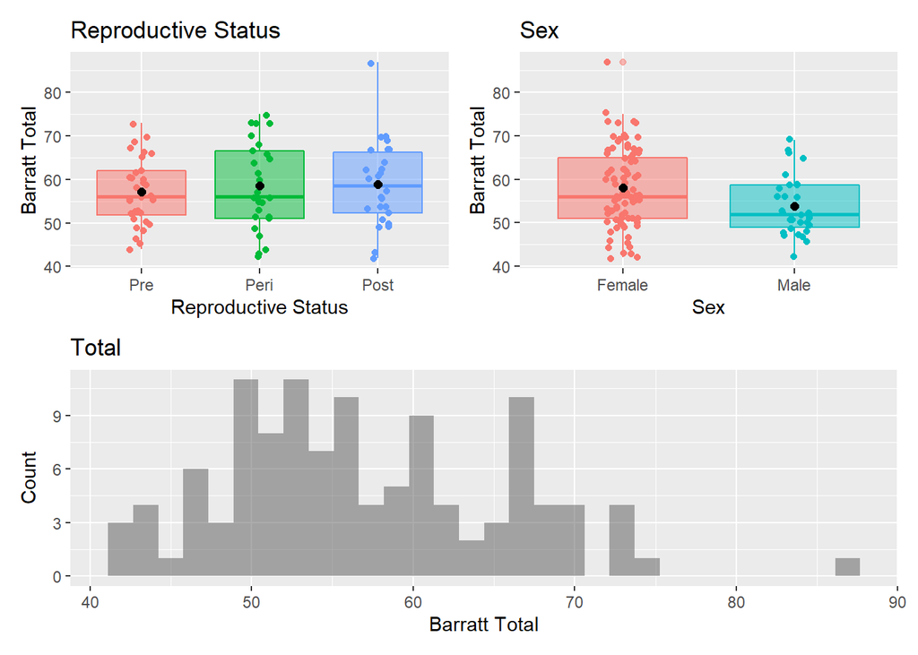

Barratt questionnaire also breaks down the composite/total score into sub-components. Specific questions are categorized into one of these components:

- **Attention:** attention and cognitive instability
- **Motor:** motor and perseverance
- **Non-Planning:** self-control and cognitive complexity

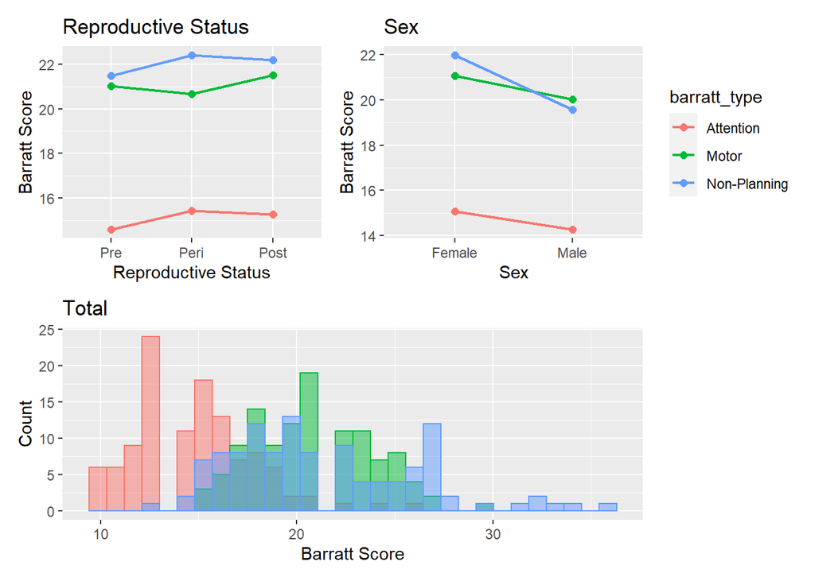

## Medical Outcomes

General health index of participants. Scores are the weighted sums of the questions in each section

- Lower scores = more disability
- Higher scores = less disability

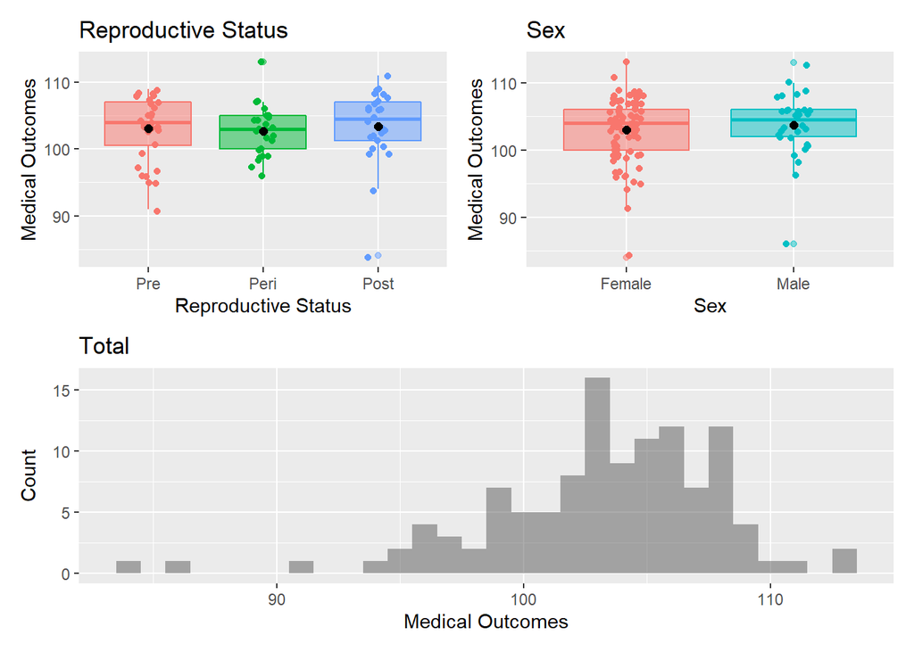

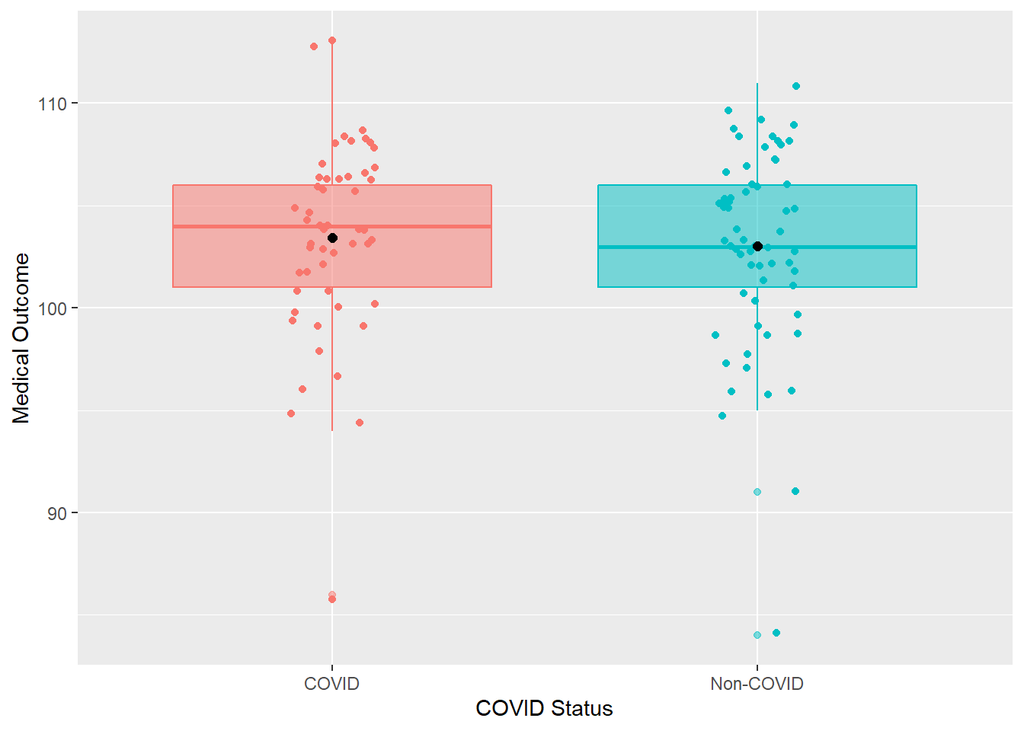

No difference in medical outcomes between the two groups.

## BAS & BIS

**Behavioral Avoidance Scale (BAS)** measures motivation to approach goal-oriented outcomes. Statements ranked by participants are categorized into specific motivators for BAS

- Drive
- Fun seeking
- Reward responsiveness

Total is the composite score for BAS, which is the sum of scores from the three subscales

- Higher scores = higher motivation for goal-oriented outcomes

**Overall/Total**

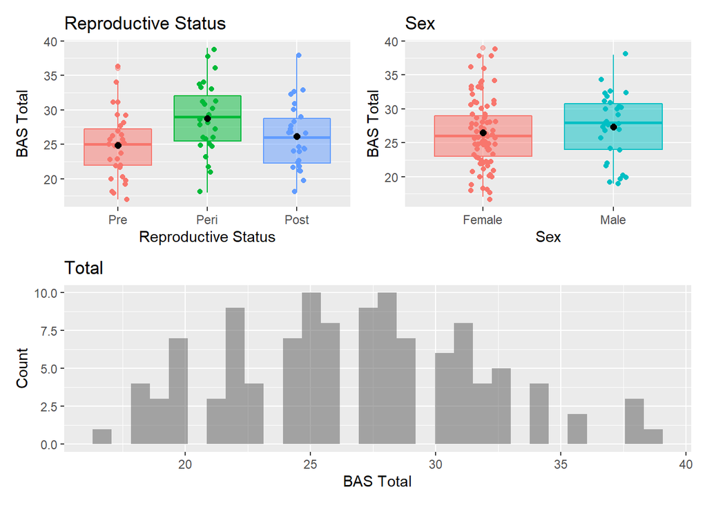

We can also view how these subscales differ by reproductive status and sex

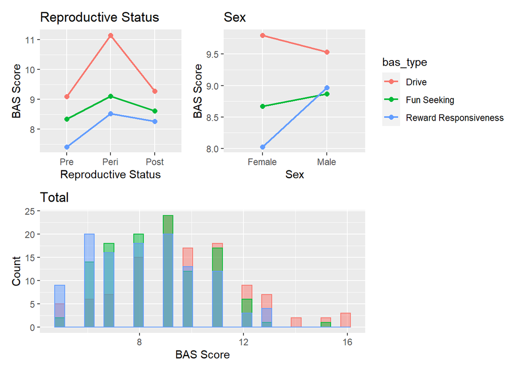

**Behavioral Inhibition Scale (BIS)** measures motivation to avoid aversive outcomes

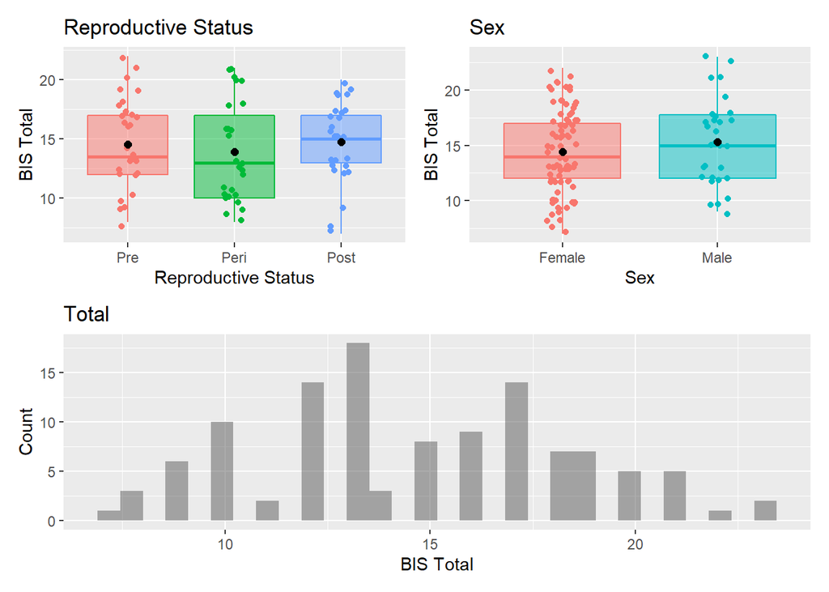

## Perceived Stress

Measures participant’s perceived stress. There is a potential relationship with perceived stress and health; Cohen et al. (1988) show correlations with PSS and: Stress Measures, Self-Reported Health and Health Services Measures, Health Behavior Measures, Smoking Status, Help Seeking Behavior.

- Higher scores = more perceived stress

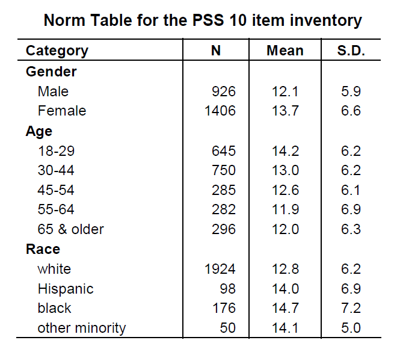

L. Harris Poll gathered information on 2,387 respondents in the U.S. for normative data (from Sheldon Cohen, 1994)

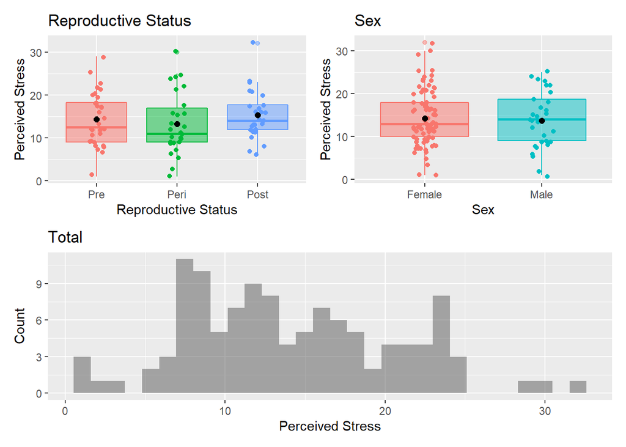

Because of the possible correlation with health outcomes, I decided to plot perceived stress scores and the medical health outcome scores to see if there is a possible trend

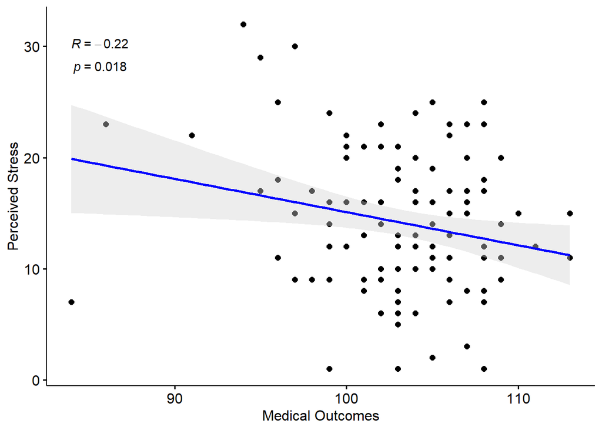

Less disability (higher medical outcomes score) is associated with less perceived stress.

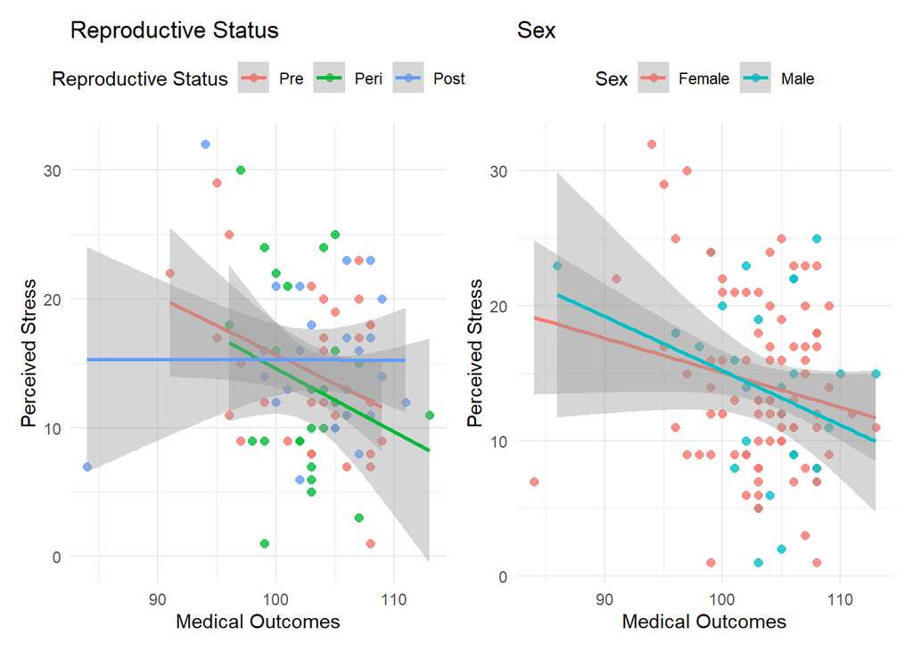

Is there more perceived stress for participants due to the pandemic? I explore whether participants feel more stressed when recruited during the pandemic.

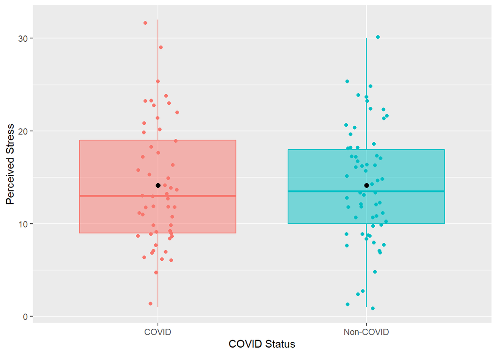

No differences in perceived stress between “COVID” and “Non-COVID” groups.

## SSS Community Ladder

Measures the participant’s perceived social standing within their community. Scores range from 1-10.

- Higher scores = more perceived social standing

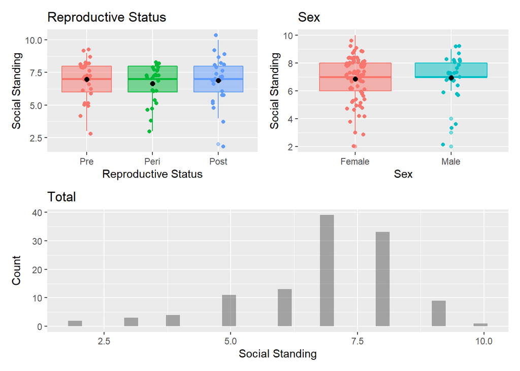

## SSS US Ladder

Measures the participant’s perceived social standing within the United States. Scores range from 1-10.

- Higher scores = more perceived social standing

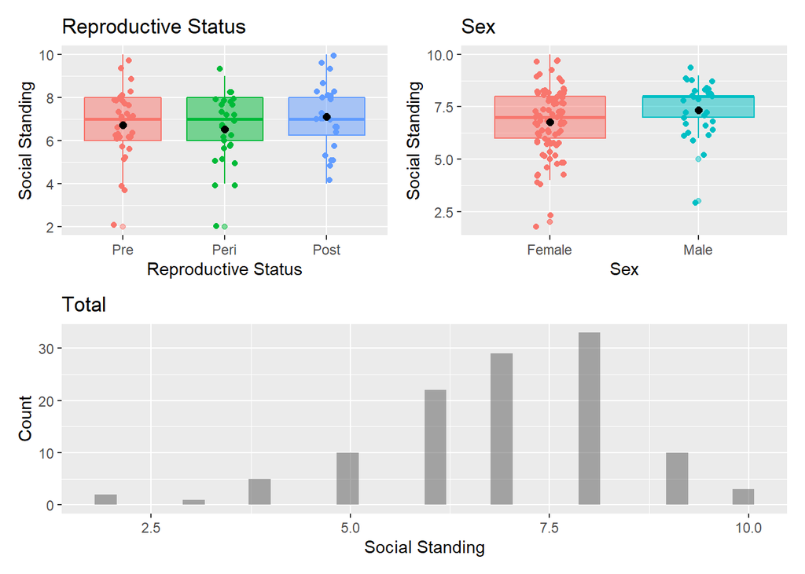

## Geriatric Depression

Measures participant depression

- Scores ranging 0-5 are considered normal
- Scores that are 5+ suggest depression

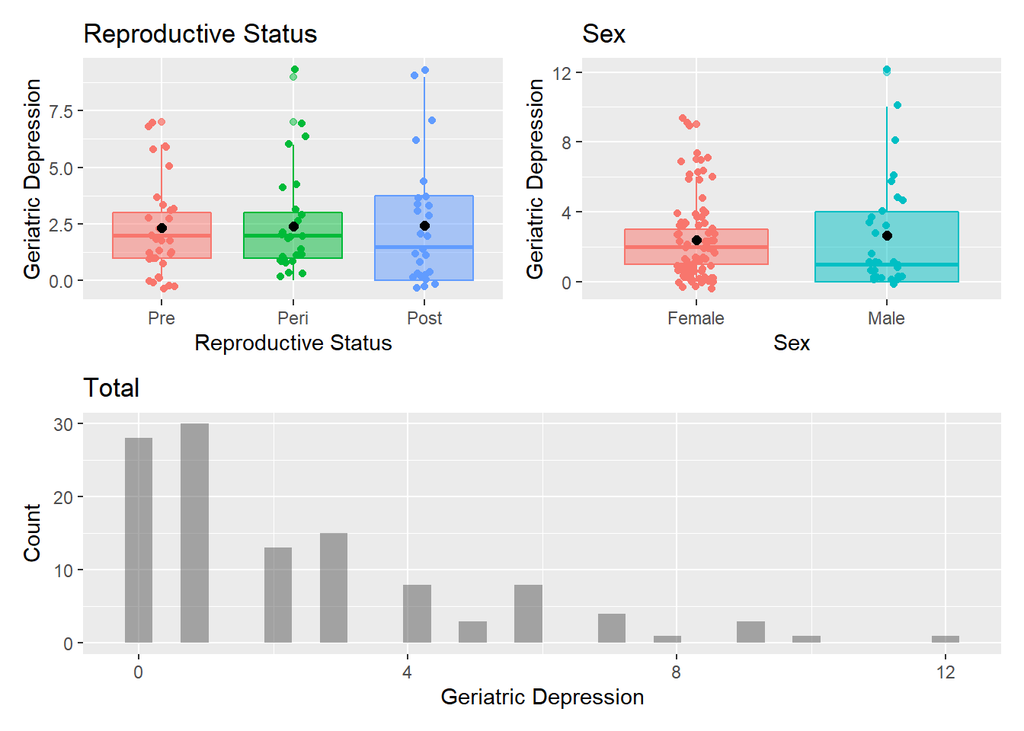

There are plenty of participants whose scores were 5+, but may be due to COVID depression.

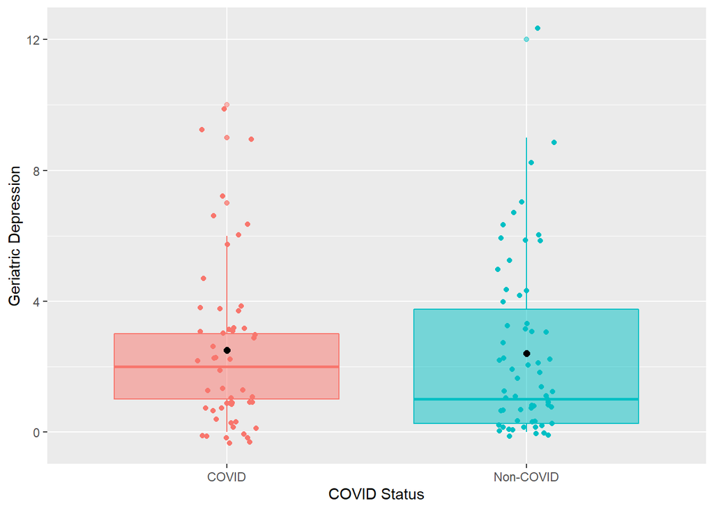

No differencs between the two groups.

Scale was developed by Sheikh & Yesavage, 1986. Times are a lot different now and there is lots to be sad about (i.e., general depression is normalized)

## PSQI

Pittsburgh Sleep Quality Index. Measures quality of sleep by taking into account 7 components: habitual sleep efficiency, subjective sleep quality, sleep duration, sleep latency, use of sleep medications, sleep disturbances, and daytime dysfunction.

Each component is given a score from 0-3, with 0 meaning no difficulty and 3 meaning having severe difficulty.

The PSQI score thus ranges from 0-21:

- Scores of 0 = No difficulty sleeping
- Score of 21 = Severe difficulties in all components/areas

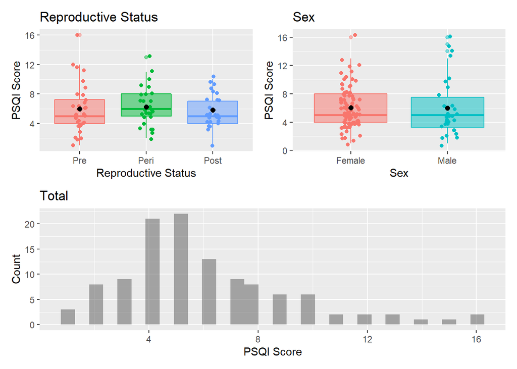

## LCA Total

Lifetime Cognitive Activity (LCA) measures participant’s cognitive enrichment through activities they have experienced overall

Includes scores from ages 6, 12, 18, and present

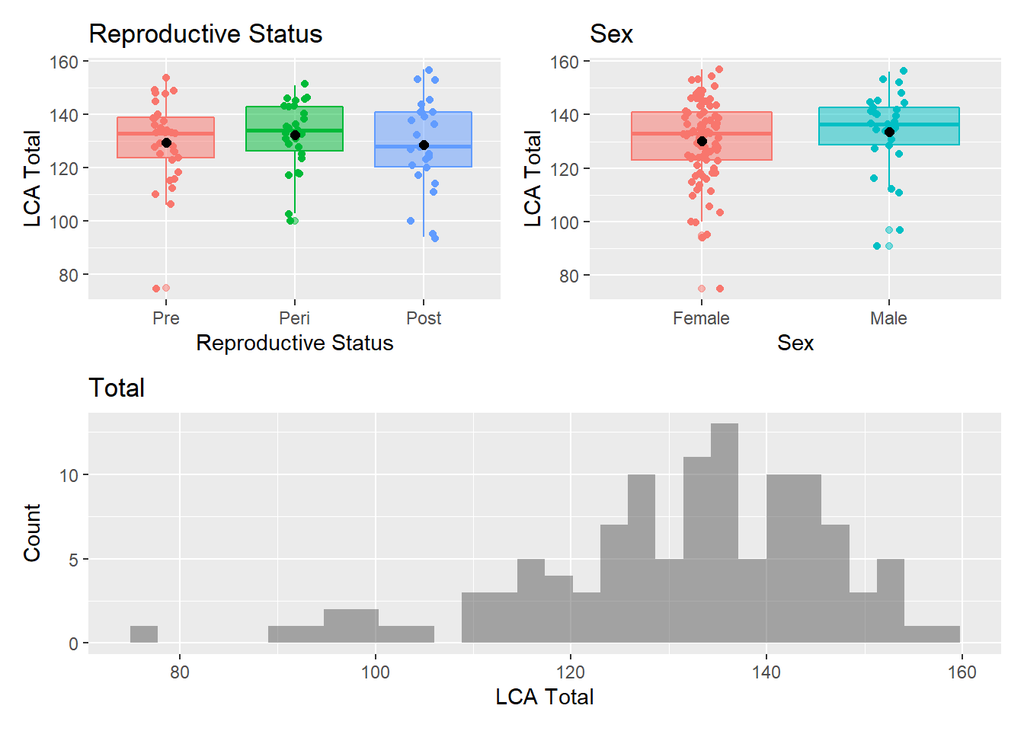

We ask participants in general, all else being same, how often they would do certain activities. Some may have thought about the present time and activities they can’t do during the pandemic, such as going to museums. I also checked whether there are differences between particants recruited pre- and during pandemic.

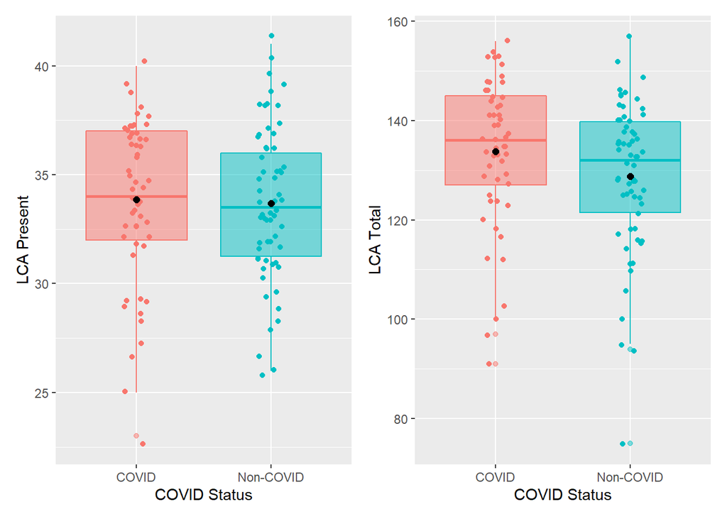

## LTPA Total

Leisure Time Physical Activity (LTPA) measures participant’s intensity and frequency of physical activity based on rate of energy expenditure. Participants rate activities they have participated in the last 12 months at the time they take the survey. Activities have been categorized as light, moderate, or heavy.

Activity Metabolic Index (AMI) scores are duration of time participant spend on activity multiplied by the metabolic equivalent (MET) intensity code of the specific activity. The total LTPA is a sum of the AMI scores from light, moderate, and physical activities.

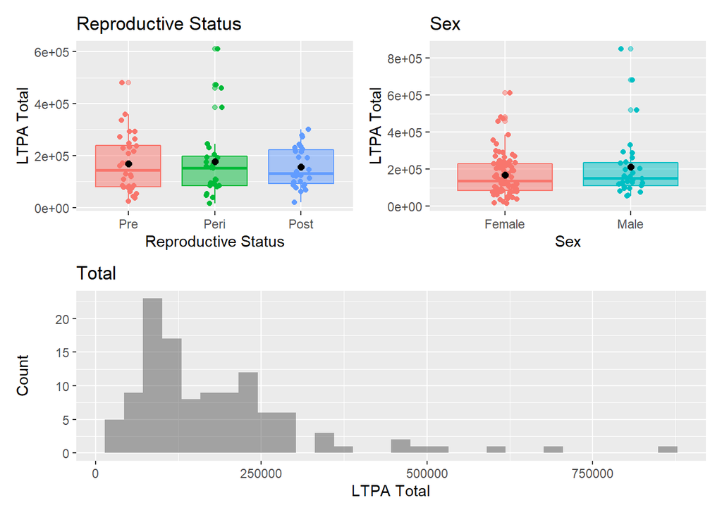

Given that this asks participants’ physical activity in just the last 12 months, COVID may have changed how often they go outside or change their exercise habits. I explore whethere there is a difference in total LTPA scores between participants who were in the study pre-pandemic and those who were recruited during the pandemic.

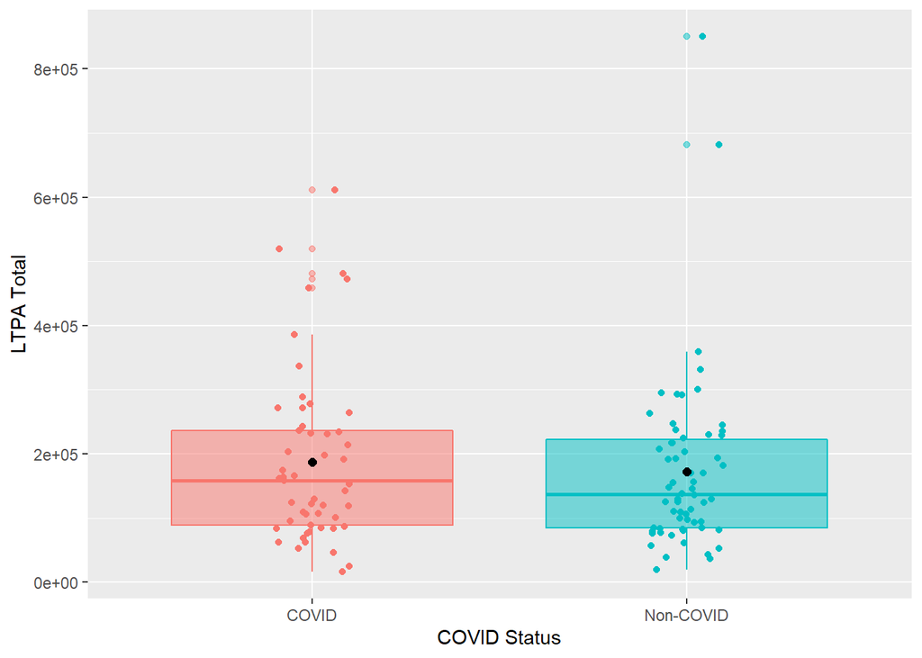

There is no difference in physical activity between subjects recruited pre-pandemic and during pandemic.

## POMS

Profile of Mood States (POMS) measures participant’s current feelings or transient, direct mood states

Participants rate how much they agree with feeling certain moods currently, and moods are categorized as the following with range of scores:

- **Tension:** 9-45
- **Depression:** 15-75
- **Anger:** 12-60
- **Fatigue:** 7-35
- **Confusion:** 7-35
- **Vigour:** 8-40
- **TMD:** 10-242

TMD is Total Mood Disturbance, which is the composite score for POMS

**Overall/Total**

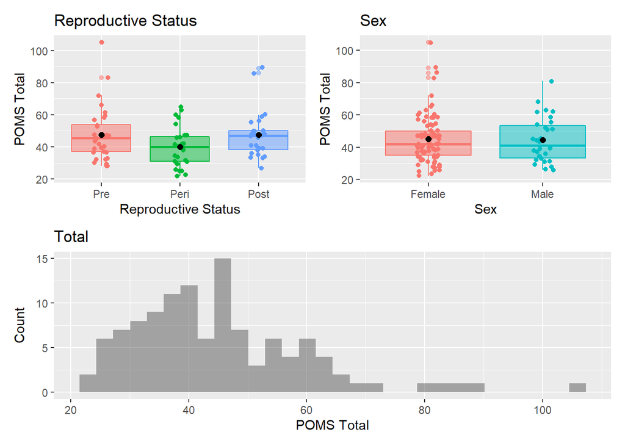

We can also look at the other components of POMS

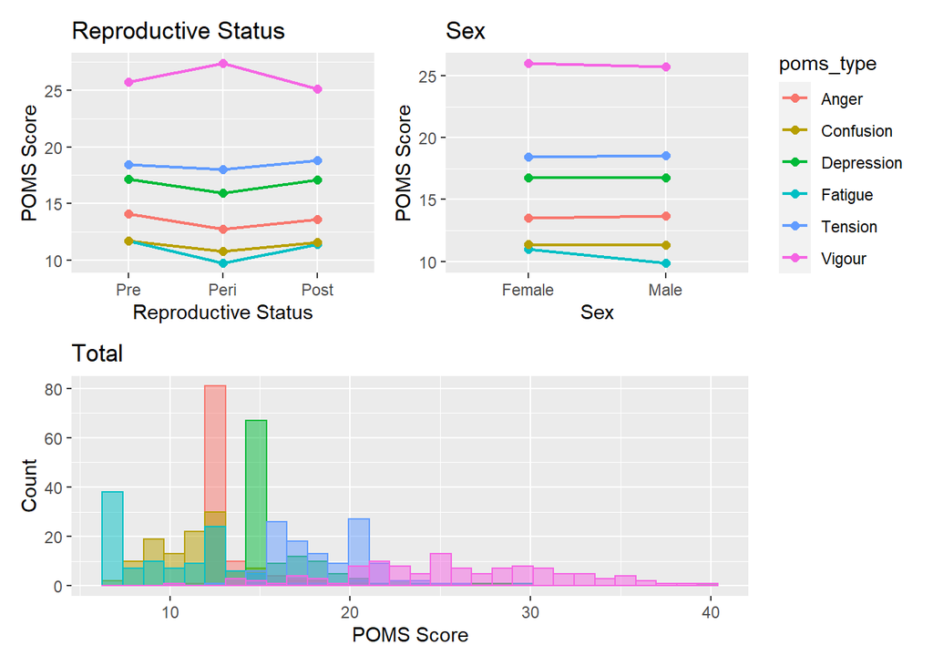